# One way analysis of variance

You should work through the exercises step-by-step, following the instructions carefully. At various points we will interrupt the flow of instructions with a question. Make a note of your answers so that you can complete the MOLE quiz for this week.

### Lead pollution in lakes

The United States Water Quality and Purity Board have been monitoring the concentrations of lead in trout in lakes in New York State because of concern about toxic concentrations of lead in the food-chain, especially in trout and the birds feeding on them. Two of the lakes (Kelvin and Beaver) are surrounded by agricultural land. The other three lakes (Allsopp, Anglers and Rocky) are adjacent to built-up and industrial areas.

Data for lead in trout in the lakes are in a CSV file LAKEPB.CSV. The measurements are the concentration of lead (mg kg<sup>-1</sup>) from 6 randomly sampled trout in each lake. The concentration measurements are stored in the `Lead` variable and the lake codes are in the `Lake` variable.

Read this data file into R, explore the data visually using a box and whiskers plot, and then proceed to fit a one-way ANOVA model with the `lm` function. Use the `plot` function on the resulting fitted model object to evaluate whether or not the data conform to the assumptions of ANOVA:

**MOLE question**

Do you feel the data conform acceptably to the assumptions of ANOVA?

Next, assume the assumptions are met and carry out the global significance test to evaluate whether the means are different. Write a concise summary of the results from the ANOVA:

**MOLE question**

Summary:

Do you have any comments on the possible biological reasons for the patterns you see in the data?

Finally, produce a ‘publication ready’ bar plot that shows the mean and standard erros of the lead concentration in each lake. It should look similar to this:

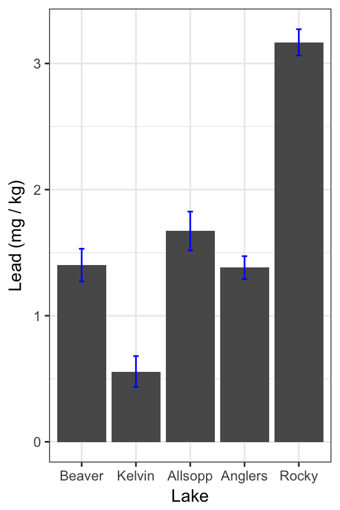

### The effect of molluscicide on rates of movement in slugs

Garden slugs of the same species and approximately the same size were given either a full dose, a half strength dose, or a one tenth strength dose of a molluscicide (‘Slugit’) dissolved in water. A control group were treated with just water. The rate of movement of the slugs on a moist wooden board after treatment was recorded (cm per min). There were 8 replicate slugs for each treatment.

The data are stored in a CSV file SLUGIT.CSV. The rate of movement is stored in the `Distance` variable and the treatment codes are in the `SlugitTreat` variable (levels: ‘full dose’, ‘half dose’, ‘one tenth dose’, ‘control’). Read in the data, explore them using a multi-panel dot plot, and then fit a one-way ANOVA model.

Use the exploratory plot and fitted model to evaluate the assumptions of ANOVA:

**MOLE question**

Do you feel the data conform acceptably to the assumptions on ANOVA?

- Data type?
- Normally distributed?
- Similar variances in each treatment?

If the data are appropriate carry out the global significance test and write a concise summary of the results from the ANOVA:

**MOLE question**

What are the results from the ANOVA?

**MOLE question**

Write a summary of the results from the analysis.

Produce a ‘publication ready’ plot similar to the one below:

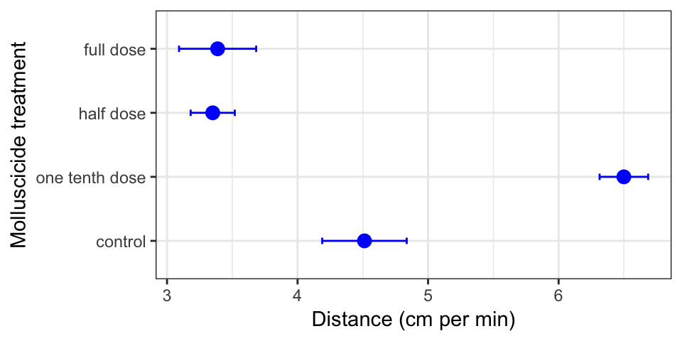

### Multiple comparisons — slug movement and molluscicide

Return to the slug molluscicide exercise and carry out the Tukey HSD test on the movement rates of slugs following different doses of Slugit.

**MOLE question**

Prepare a summary of differences between means.

**MOLE question**

Comment on any features of biological interest in the results.